# Support Vector Machines

Dani Bauer

In this tutorial, we discuss **Support Vector Machines** and demonstrate their implementation in `R`. We first consider their performance in a simulated example. We then use them in our case study examples, analyzing whether they can improve on the learners considered so far.

```r
rm(list=ls())
#install.packages("e1071")
#install.packages("ggplot2")
```

Let’s again define:

```r
TPR <- function(y,yhat)  { sum(y==1 & yhat==1) / sum(yhat==1) }
```

# Support Vector Machines

## Review of Concepts and Maths

The intellectual starting point for SVMs is that:
$$f(x) = \beta_0 + \beta_1\,x_1 + \beta_2\,x_2 + \ldots + \beta_p\,x_p = 0$$
defines a *hyperplane*, and we can define a *binary linear classifier* according to
$$f(x^{(0)}) \begin{array}{c} >\\<\end{array} 0,$$
(where points fall relative to that hyperplane). We can determine a hyperplane that maximizes the distance to the two classes, allowing for exceptions. It turns out that only a few points where the distances are sharp or that are exceptions matter, these are called *support vectors*.

This idea generalizes to non-linear functions $f(\cdot)$:
$$f(x) = 0$$
defines a boundary, and we can classify according to
$$f(x^{(0)}) \begin{array}{c} >\\<\end{array} 0.$$
SVMs use *kernel functions* to define non-linear $f$’s that work particularly well.

## Setup

We start out by setting the scene: We set a seed and we load various packages. The package `e1071` is the where the SVM functionality is provided (so you may have to instal it). In addition we load packages that allow us to illustrate the data and packages to run comparisons.

```r
library(ggplot2)
library(e1071)
library(MASS)
set.seed(3)
```

Let’s consider some arbitrary predictors in two-dimensional space, $x_1$ and $x_2$:

```r
x_1 <- 2 * rnorm(100)
x_2 <- 2 * rnorm(100)
```

As we discussed above, the equation $f(x_1,x_2) = 0$ fixes a boundary in the two-dimensional space, so the “true” classification may be done according to:
$$f(x_1,x_2) \;\; \begin{array}{c}>\\< \end{array} \;\; 0.$$
We rely on the example that was used in generating the (non-linear) plot from lecture:

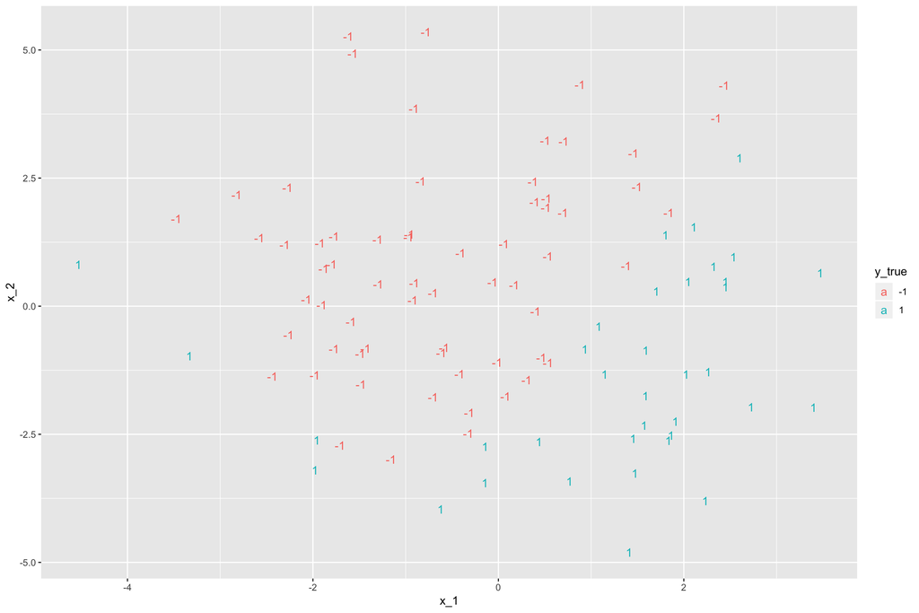

```r
y_true <- factor(sign(5 * sin(0.5 * (x_1 - 2)) + 2 - x_2))
mydata_true <- data.frame(y_true,x_1,x_2)
ggplot(mydata_true) + geom_text(aes(x_1,x_2,label=y_true,colour=y_true))
```

To generate more realistic data sets, where the classification is not sharp along the boundary, let’s add noise. We consider two different examples, one with less noise – labeled 1 – and one with more noise – labeled 2.

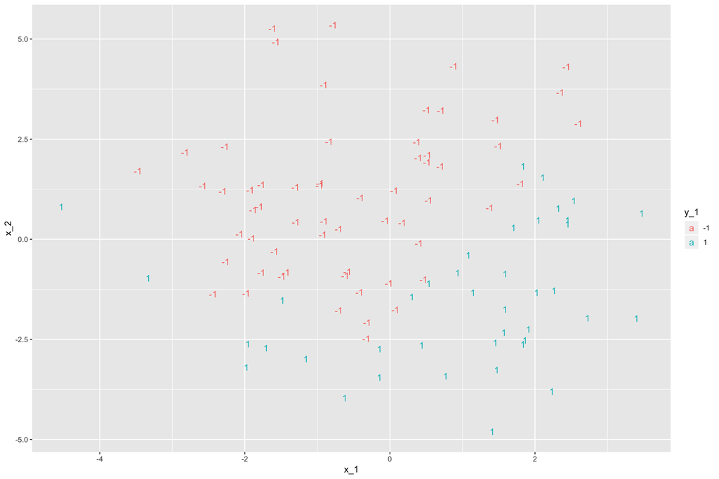

```r
y_1 <- factor(sign(5 * sin(0.5 * (x_1 - 2)) + 2 - x_2 +  1 * rnorm(100)))
mydata_1 <- data.frame(y_1,x_1,x_2)
ggplot(mydata_1) + geom_text( aes(x_1,x_2,label=y_1,colour=y_1))
```

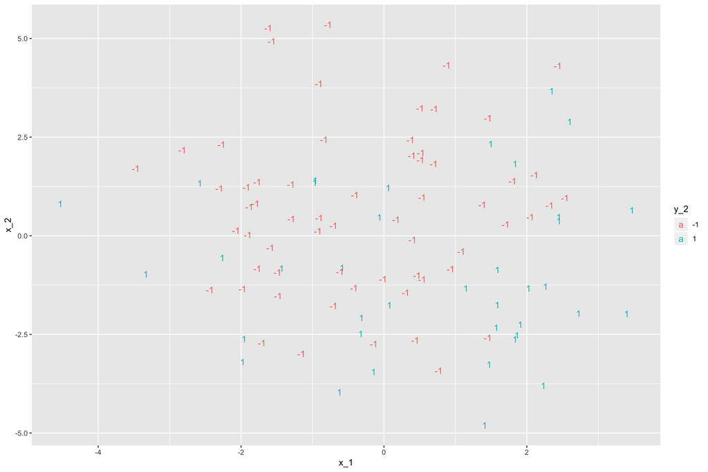

```r
y_2 <- factor(sign(5 * sin(0.5 * (x_1 - 2)) + 2 - x_2 +  3.5 * rnorm(100)))
mydata_2 <- data.frame(y_2,x_1,x_2)
ggplot(mydata_2) + geom_text( aes(x_1,x_2,label=y_2,colour=y_2))
```

## Simulated Example I: Well-Separated Classes

Let’s start out with the first example, where there is little noise such that the classes are well-separated. Let’s run our first SVM classifier (see [the package `e1071`](https://cran.r-project.org/web/packages/e1071/e1071.pdf) for more details):

```r
svm_1_rad <- svm(y_1 ~ . , data = mydata_1, kernel="radial", gamma=1.0, cost=10)
#Other kernel options are linear, polynomial, radial, sigmoid
summary(svm_1_rad)
```

```
Call:
svm(formula = y_1 ~ ., data = mydata_1, kernel = "radial", gamma = 1,
    cost = 10)


Parameters:
   SVM-Type:  C-classification
 SVM-Kernel:  radial
       cost:  10
      gamma:  1

Number of Support Vectors:  30

 ( 15 15 )


Number of Classes:  2

Levels:
 -1 1
```

```r
table(svm_1_rad$fitted, y_1)
```

```
    y_1
     -1  1
  -1 58  2
  1   2 38
```

```r
table(svm_1_rad$fitted, y_true)
```

```
    y_true
     -1  1
  -1 59  1
  1   5 35
```

One has to choose a kernel, a `gamma` parameter that is associated with the kernel (the higher, the more non-linear), as well as a `cost` parameter. All are tuning parameters. Here, the `gamma` was chosen to roughly optimize the predictions (relative to the “true” data set), so some tuning was done. In this case, the number of support vectors is relatively low (30).

We observe that the SVM does very well, the misclassification error is only 6%.

Let’s compare to *Quadratic Discriminant Analysis* (QDA):

```r
qda_1 <- qda(y_1 ~ ., data = mydata_1)
pred_qda_1 <- predict(qda_1, mydata_1)
table(pred_qda_1$class, y_1)
```

```
    y_1
     -1  1
  -1 53  5
  1   7 35
```

```r
table(pred_qda_1$class, y_true)
```

```
    y_true
     -1  1
  -1 53  5
  1  11 31
```

Clearly QDA does not work as well in that it is not able to capture the pattern well. On the other hand, a very flexible learner may overfit the data. Hence, the SVM seems to be doing a nice job: It allows to capture the pattern but, at the same time, is sufficiently “simple” so that, when tuning appropriately, over-fitting can be mitigated.

## Simulated Example II: Poor Separation

Now let’s look at the second data set where the data is less well-separated. Let’s again fit the SVM, using the same choices (after all, the “true” pattern is the same):

```r
svm_2_rad <- svm(y_2 ~ . , data = mydata_2, kernel="radial", gamma=1.0, cost=10)
summary(svm_2_rad)
```

```
Call:
svm(formula = y_2 ~ ., data = mydata_2, kernel = "radial", gamma = 1,
    cost = 10)


Parameters:
   SVM-Type:  C-classification
 SVM-Kernel:  radial
       cost:  10
      gamma:  1

Number of Support Vectors:  60

 ( 31 29 )


Number of Classes:  2

Levels:
 -1 1
```

```r
table(svm_2_rad$fitted, y_2)
```

```
    y_2
     -1  1
  -1 61 17
  1   1 21
```

```r
table(svm_2_rad$fitted, y_true)
```

```
    y_true
     -1  1
  -1 63 15
  1   1 21
```

With 16%, the error rate is substantially larger, and the number of support vectors is significantly greater (60).

Let’s compare to QDA:

```r
qda_2 <- qda(y_2 ~ ., data = mydata_2)
pred_qda_2 <- predict(qda_2, mydata_2)
table(pred_qda_2$class,y_2)
```

```
    y_2
     -1  1
  -1 55 18
  1   7 20
```

```r
table(pred_qda_2$class,y_true)
```

```
    y_true
     -1  1
  -1 64  9
  1   0 27
```

Hence, while for QDA the in-sample error is higher than for the SVM classifier (25% vs. 18%), the “true” error is lower for the QDA (9% vs. 16%). Thus, at least in this example, QDA outperforms the SVM.

Hence, it appears that SVM is doing particularly well in the first context where the classes are well separated.

## Case Study I: Caravan Insurance Purchases

Let’s go back to the `Caravan` insurance data:

```r
library(ISLR)
data(Caravan)
dat <- Caravan
dat$Purchase <- I(dat$Purchase=="Yes")*1
X <- scale(dat[,1:85])
tst <- 1:1000
X.trn <- X[-tst,]
X.tst <- X[tst,]
Y.trn <- dat[-tst,86]
Y.tst <- dat[tst,86]
train <- dat[-tst,]
test <- dat[tst,]

xvars <- names(dat)[-86]
```

As a reminder, the lasso-logistic regression model achieved by an AUC of 0.7456.

### K-Nearest Neighbor

Let’s first consider the **k-nearest neighbor (knn)** approach, where the predicted class at a point $x_0$ is chosen based on the $k$ points that are closest:
$$y(x_0) = \max_j\left\{\frac{1}{K} \sum_{i \in N_K(x_0)} 1_{\{y_i=j\}}\right\},$$
where $N_k(x_0)$ denotes the index set of the $K$ points in the training sample that are closest to the point $x_0$ (usually in the sense of Euclidean distance).

Let’s try:

```r
library(class)
set.seed(1)
pred.knn.1 <- knn(X.trn, X.tst, Y.trn, k=1)
table(pred.knn.1, Y.tst)
```

```
          Y.tst
pred.knn.1   0   1
         0 873  50
         1  68   9
```

```r
TPR(Y.tst, pred.knn.1)
```

```
[1] 0.1168831
```

```r
pred.knn.3 <- knn(X.trn, X.tst, Y.trn, k=3)
table(pred.knn.3, Y.tst)
```

```
          Y.tst
pred.knn.3   0   1
         0 920  54
         1  21   5
```

```r
TPR(Y.tst, pred.knn.3)
```

```
[1] 0.1923077
```

```r
pred.knn.5 <- knn(X.trn, X.tst, Y.trn, k=5)
table(pred.knn.5, Y.tst)
```

```
          Y.tst
pred.knn.5   0   1
         0 930  55
         1  11   4
```

```r
TPR(Y.tst, pred.knn.5)
```

```
[1] 0.2666667
```

```r
pred.knn.10 <- knn(X.trn, X.tst, Y.trn, k=10)
table(pred.knn.10, Y.tst)
```

```
           Y.tst
pred.knn.10   0   1
          0 941  59
          1   0   0
```

```r
TPR(Y.tst, pred.knn.10)
```

```
[1] NaN
```

So while it is not immediately clear how to obtain *class probabilities* as for the previous learners, we can identify some potential purchasers by simply mimicking similar observations.

### SVM

Let’s try the SVM:

```r
svm_pars <- tune.svm(Purchase~.,data=train, kernel="radial", gamma = 10^(-5:-1), cost = 10^(-3:1), cross=5)
```

[output not shown]

[output cut: 697 more lines]

[output not shown]

```r
#this takes a bit to run, so be patient or reduce the set of parameters
summary(svm_pars)
```

```
Parameter tuning of 'svm':

- sampling method: 10-fold cross validation

- best parameters:
 gamma cost
   0.1    1

- best performance: 0.05735264

- Detailed performance results:
   gamma  cost      error dispersion
1  1e-05 1e-03 0.05765973 0.01239853
2  1e-04 1e-03 0.05766014 0.01239878
3  1e-03 1e-03 0.05765916 0.01239901
4  1e-02 1e-03 0.05765789 0.01239777
5  1e-01 1e-03 0.05765259 0.01239583
6  1e-05 1e-02 0.05766012 0.01239874
7  1e-04 1e-02 0.05766049 0.01239849
8  1e-03 1e-02 0.05765947 0.01239870
9  1e-02 1e-02 0.05765584 0.01239614
10 1e-01 1e-02 0.05764620 0.01239320
11 1e-05 1e-01 0.05766265 0.01239965
12 1e-04 1e-01 0.05766040 0.01239882
13 1e-03 1e-01 0.05765829 0.01239658
14 1e-02 1e-01 0.05763149 0.01237947
15 1e-01 1e-01 0.05755269 0.01235616
16 1e-05 1e+00 0.05766019 0.01239863
17 1e-04 1e+00 0.05766032 0.01239864
18 1e-03 1e+00 0.05763963 0.01238059
19 1e-02 1e+00 0.05752629 0.01219486
20 1e-01 1e+00 0.05735264 0.01185003
21 1e-05 1e+01 0.05766025 0.01239888
22 1e-04 1e+01 0.05765692 0.01239588
23 1e-03 1e+01 0.05756640 0.01220580
24 1e-02 1e+01 0.05984445 0.01111225
25 1e-01 1e+01 0.06946620 0.00942578
```

So out of the chosen parameters, `gamma = 0.1` and `cost = 1` perform best. Let’s run the SVM on that basis:

```r
svm1 <- svm(Purchase~.,data=train, kernel="radial", gamma = 0.1, cost = 1)
summary(svm1)
```

```
Call:
svm(formula = Purchase ~ ., data = train, kernel = "radial", gamma = 0.1,
    cost = 1)


Parameters:
   SVM-Type:  eps-regression
 SVM-Kernel:  radial
       cost:  1
      gamma:  0.1
    epsilon:  0.1


Number of Support Vectors:  3368
```

And let’s evaluate the predictions:

```r
pred.svm1 <- predict(svm1, newdata = test)
head(pred.svm1)
```

```
         1          2          3          4          5          6
0.01945772 0.03644547 0.02394100 0.03604584 0.03101688 0.02365247
```

```r
sum(pred.svm1>0.5)
```

```
[1] 0
```

```r
table(pred.svm1>0.1, test$Purchase)
```

```
          0   1
  FALSE 916  55
  TRUE   25   4
```

```r
library("pROC")
svm1.roc <- roc(test$Purchase, pred.svm1, direction="<")
svm1.roc
```

```
Call:
roc.default(response = test$Purchase, predictor = pred.svm1,     direction = "<")

Data: pred.svm1 in 941 controls (test$Purchase 0) < 59 cases (test$Purchase 1).
Area under the curve: 0.6055
```

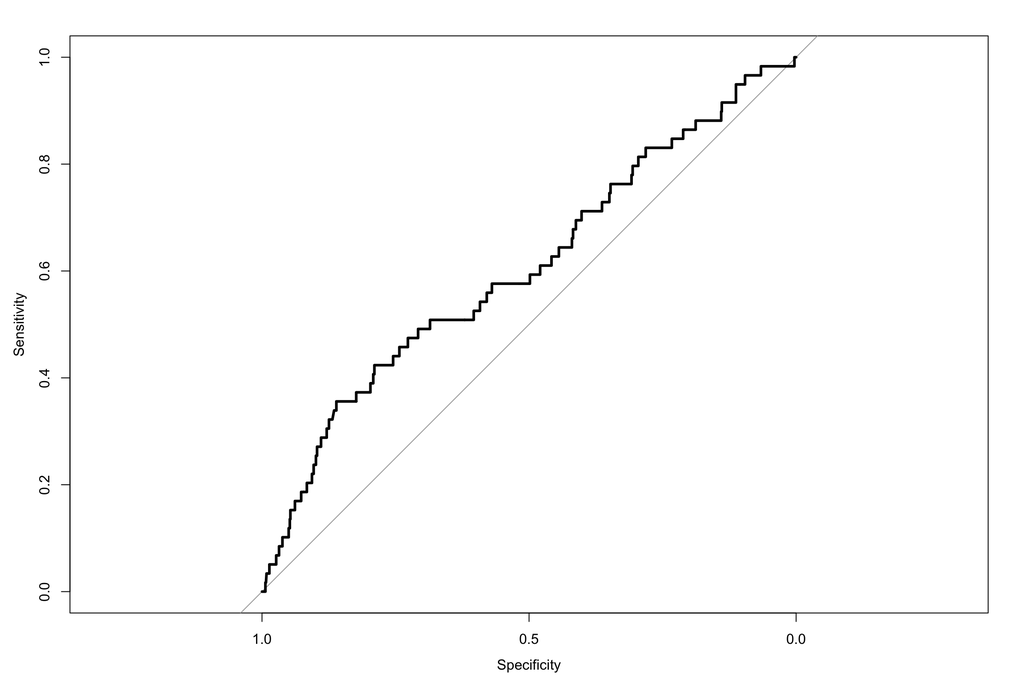

```r
plot(svm1.roc, lwd=3)
```

## Case Study II: Credit Card Defaults

Let’s go back to our second example, where we only consider a few of the factor `PAY` variables given our previous experiences, and limitations of these methods with categorical variables.

```r
mydata <- readRDS("my_UCICredit_data.rds")
mydata <- mydata[,c(1:11,13:14,16,20)]
str(mydata)
```

```
'data.frame':   30000 obs. of  15 variables:
 $ LIMIT_BAL: num  -1.137 -0.366 -0.597 -0.905 -0.905 ...
 $ AGE      : num  -1.246 -1.029 -0.161 0.164 2.334 ...
 $ BILL_REC : num  -0.6425 -0.6592 -0.2986 -0.0575 -0.5786 ...
 $ BILL_AVG : num  -0.658 -0.632 -0.422 -0.102 -0.396 ...
 $ PAY_AMT1 : num  -0.342 -0.342 -0.25 -0.221 -0.221 ...
 $ PAY_AMT2 : num  -0.227 -0.214 -0.192 -0.169 1.335 ...
 $ PAY_AMT3 : num  -0.297 -0.24 -0.24 -0.229 0.271 ...
 $ PAY_AMT4 : num  -0.308 -0.244 -0.244 -0.238 0.266 ...
 $ PAY_AMT5 : num  -0.314 -0.314 -0.249 -0.244 -0.269 ...
 $ PAY_AMT6 : num  -0.2934 -0.1809 -0.0121 -0.2371 -0.2552 ...
 $ SEX      : Factor w/ 2 levels "1","2": 2 2 2 2 1 1 1 2 2 1 ...
 $ MARRIAGE : Factor w/ 4 levels "0","1","2","3": 2 3 3 2 2 3 3 3 2 3 ...
 $ PAY_0    : Factor w/ 7 levels "-2","-1","0",..: 5 2 3 3 2 3 3 3 3 1 ...
 $ PAY_3    : Factor w/ 7 levels "-2","-1","0",..: 2 3 3 3 2 3 3 2 5 1 ...
 $ default  : Factor w/ 2 levels "0","1": 2 2 1 1 1 1 1 1 1 1 ...
```

```r
set.seed(42)
index <- sort(sample(1:nrow(mydata),round(0.75*nrow(mydata))))
train <- mydata[index,]
test  <- mydata[-index,]
```

As a reminder, the AUC for the GAM was 0.7754 and the confusion table for a GLM with 50% cutoff was:
$$\begin{array}{l c c}
& \text{Y.tst} &&\\
\text{FALSE} & 5572 & 1033\\
\text{TRUE} & 272 & 623
\end{array}$$

### kNN

Let’s see if the knn delivers here:

```r
X.trn <- train[,1:19]
```

[output not shown]

```r
X.tst <- test[,1:19]
```

[output not shown]

```r
Y.trn <- train[,20]
```

[output not shown]

```r
set.seed(1)
pred.knn.3 <- knn(X.trn, X.tst, Y.trn, k=3)
table(pred.knn.3, test$default)
```

[output not shown]

```r
pred.knn.5 <- knn(X.trn, X.tst, Y.trn, k=5)
table(pred.knn.5, test$default)
```

[output not shown]

```r
pred.knn.10 <- knn(X.trn, X.tst, Y.trn, k=10)
table(pred.knn.10, test$default)
```

[output not shown]

### SVM

Let’s start with the SVM, where we use cross validation to determine the accuracy. Since it takes a while to run each fit, rather than using a tuning routine, let’s perform a manual search:

```r
#Again, these take a while.  Consider limiting the number of covariates if it takes too lonng (e.g. only some PAY variables)
mod_svm_1 <- svm(default ~ LIMIT_BAL +  AGE + PAY_0 + PAY_3 + BILL_REC + BILL_AVG + PAY_AMT1 + PAY_AMT2 + PAY_AMT3 + PAY_AMT4 + PAY_AMT5 + PAY_AMT6, data = train, kernel="radial", gamma = 0.5, cost=1, cross=5)
mod_svm_1$tot.accuracy
```

```
[1] 81.66222
```

```r
mod_svm_2_5 <- svm(default ~ LIMIT_BAL +  AGE + PAY_0 + PAY_3 + BILL_REC + BILL_AVG + PAY_AMT1 + PAY_AMT2 + PAY_AMT3 + PAY_AMT4 + PAY_AMT5 + PAY_AMT6, data = train, kernel="radial", gamma = 0.5, cost=2.5, cross=5)
mod_svm_2_5$tot.accuracy
```

```
[1] 81.32889
```

```r
mod_svm_5 <- svm(default ~ LIMIT_BAL +  AGE + PAY_0 + PAY_3 + BILL_REC + BILL_AVG + PAY_AMT1 + PAY_AMT2 + PAY_AMT3 + PAY_AMT4 + PAY_AMT5 + PAY_AMT6, data = train, kernel="radial", gamma = 0.5, cost=5, cross=5)
mod_svm_5$tot.accuracy
```

```
[1] 81.13333
```

```r
mod_svm_0_5 <- svm(default ~ LIMIT_BAL +  AGE + PAY_0 + PAY_3 + BILL_REC + BILL_AVG + PAY_AMT1 + PAY_AMT2 + PAY_AMT3 + PAY_AMT4 + PAY_AMT5 + PAY_AMT6, data = train, kernel="radial", gamma = 0.5, cost=0.5, cross=5)
mod_svm_0_5$tot.accuracy
```

```
[1] 81.62222
```

So it looks like a `cost = 1` delivers the best results. Let’s attempt to determine a choice for `gamma`:

```r
mod_svm_1_3 <- svm(default ~ LIMIT_BAL +  AGE + PAY_0 + PAY_3 + BILL_REC + BILL_AVG + PAY_AMT1 + PAY_AMT2 + PAY_AMT3 + PAY_AMT4 + PAY_AMT5 + PAY_AMT6, data = train, kernel="radial", gamma = 0.3, cost=1, cross=5)
mod_svm_1_3$tot.accuracy
```

```
[1] 81.8
```

```r
mod_svm_1_7 <- svm(default ~ LIMIT_BAL +  AGE + PAY_0 + PAY_3 + BILL_REC + BILL_AVG + PAY_AMT1 + PAY_AMT2 + PAY_AMT3 + PAY_AMT4 + PAY_AMT5 + PAY_AMT6, data = train, kernel="radial", gamma = 0.7, cost=1, cross=5)
mod_svm_1_7$tot.accuracy
```

```
[1] 81.56889
```

```r
mod_svm_1_1 <- svm(default ~ LIMIT_BAL +  AGE + PAY_0 + PAY_3 + BILL_REC + BILL_AVG + PAY_AMT1 + PAY_AMT2 + PAY_AMT3 + PAY_AMT4 + PAY_AMT5 + PAY_AMT6, data = train, kernel="radial", gamma = 0.1, cost=1, cross=5)
mod_svm_1_1$tot.accuracy
```

```
[1] 81.81333
```

```r
mod_svm_fin <- svm(default ~ LIMIT_BAL +  AGE + PAY_0 + PAY_3 + BILL_REC + BILL_AVG + PAY_AMT1 + PAY_AMT2 + PAY_AMT3 + PAY_AMT4 + PAY_AMT5 + PAY_AMT6, data = train, kernel="radial", gamma = 0.3, cost=1, cross=5, probability = TRUE)
summary(mod_svm_fin)
```

```
Call:
svm(formula = default ~ LIMIT_BAL + AGE + PAY_0 + PAY_3 + BILL_REC +
    BILL_AVG + PAY_AMT1 + PAY_AMT2 + PAY_AMT3 + PAY_AMT4 + PAY_AMT5 +
    PAY_AMT6, data = train, kernel = "radial", gamma = 0.3, cost = 1,
    cross = 5, probability = TRUE)


Parameters:
   SVM-Type:  C-classification
 SVM-Kernel:  radial
       cost:  1
      gamma:  0.3

Number of Support Vectors:  10918

 ( 4257 6661 )


Number of Classes:  2

Levels:
 0 1

5-fold cross-validation on training data:

Total Accuracy: 81.68889
Single Accuracies:
 82.42222 81 81.2 82.64444 81.17778
```

```r
pred_svm_fin <- predict(mod_svm_fin, newdata = test, probability = TRUE)
head(pred_svm_fin)
```

```
 2  4  7 13 17 22
 0  0  0  0  0  0
Levels: 0 1
```

```r
pred_svm_probs <- attr(pred_svm_fin, "probabilities")[,1]
head(pred_svm_probs)
```

```
        2         4         7        13        17        22
0.1638563 0.1641485 0.1763702 0.1673905 0.1665719 0.1640483
```

```r
table(pred_svm_fin, test$default)
```

```
pred_svm_fin    0    1
           0 5645 1126
           1  199  530
```

```r
library("pROC")
svm_fin.roc <- roc(test$default, pred_svm_probs, direction="<")
svm_fin.roc
```

```
Call:
roc.default(response = test$default, predictor = pred_svm_probs,     direction = "<")

Data: pred_svm_probs in 5844 controls (test$default 0) < 1656 cases (test$default 1).
Area under the curve: 0.7127
```

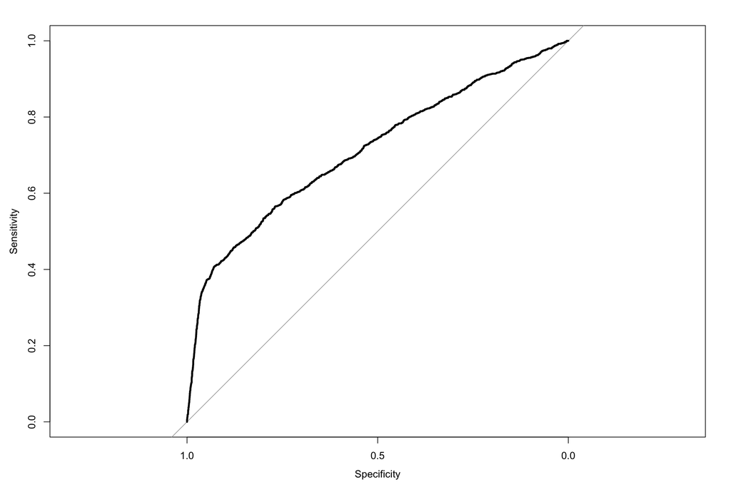

```r
plot(svm_fin.roc, lwd=3)
```